# Module R’Stat1 : ANOVA

francois.rebaudo@ird.fr

Novembre 2019 ; IRD-Montpellier-France CC BY-NC-SA 3.0

# ANOVA

## ANOVA

- Analyse de variance ou ANOVA
- *One-way analysis of variance (ANOVA)*
- *One-factor ANOVA*

sur la base des cours de L. Reboul et du “R book”.

## ANOVA : hypothèses

- les observations sont indépendantes
- pour chaque groupe (`factor`), les données suivent une loi Normale
- pour chaque groupe, la variance est la même

## ANOVA et R

```r
df <- data.frame(
  myGp = rep(1:3, times = 30),
  myData = rnorm(90)
)
print(df)
```

```
##    myGp       myData
## 1     1  0.231054022
## 2     2 -0.289179134
## 3     3 -1.280162893
## 4     1  1.072713244
## 5     2  0.215148253
## 6     3 -1.041524613
## 7     1 -1.592904833
## 8     2  0.237602054
## 9     3  0.507547292
## 10    1 -0.436476788
## 11    2 -0.827732999
## 12    3  1.816606232
## 13    1  0.496288170
## 14    2 -0.473338790
```

[output cut: 76 more lines]

## ANOVA et R

```r
str(df)
```

```
## 'data.frame':    90 obs. of  2 variables:
##  $ myGp  : int  1 2 3 1 2 3 1 2 3 1 ...
##  $ myData: num  0.231 -0.289 -1.28 1.073 0.215 ...
```

Le vecteur qui détermine le groupe doit être de type `factor` !

- Eviter les groupes 1, 2, 3
- TOUJOURS vérifier le type de données avec `str()`

## ANOVA et R

```r
df$myGp <- as.factor(df$myGp)
str(df)
```

```
## 'data.frame':    90 obs. of  2 variables:
##  $ myGp  : Factor w/ 3 levels "1","2","3": 1 2 3 1 2 3 1 2 3 1 ...
##  $ myData: num  0.231 -0.289 -1.28 1.073 0.215 ...
```

## ANOVA

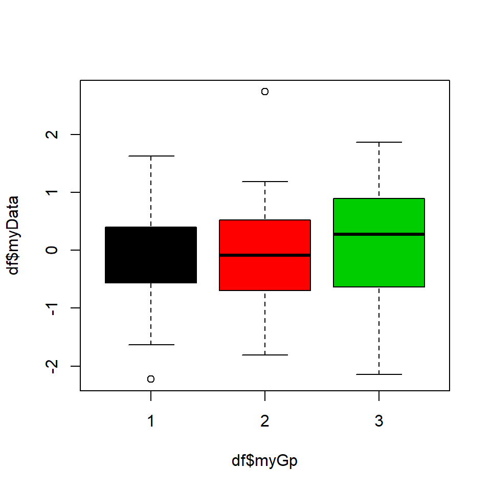

```r
boxplot(df$myData ~ df$myGp,
  col = levels(df$myGp))
```

## ANOVA

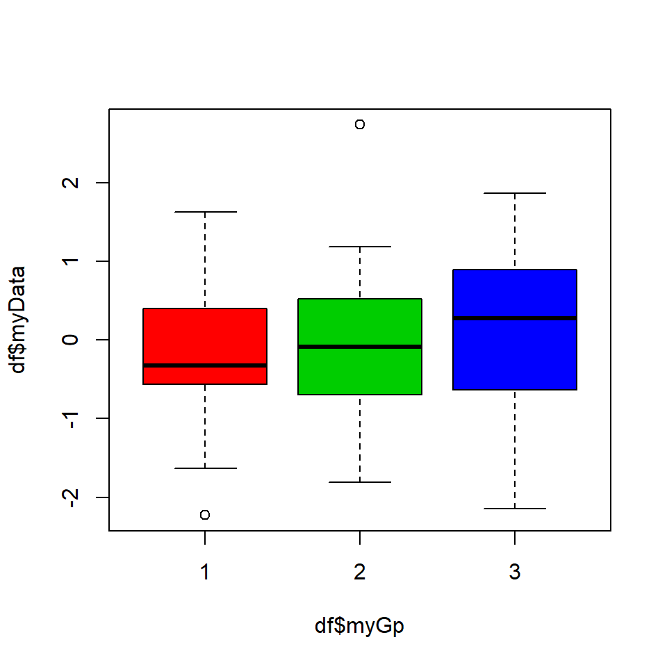

```r
boxplot(df$myData ~ df$myGp,
  col = as.numeric(levels(df$myGp)) + 1)
```

## ANOVA

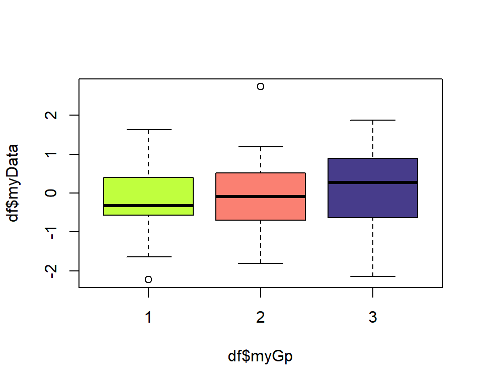

```r
myCol <- c("olivedrab1", "salmon", "slateblue4")
boxplot(df$myData ~ df$myGp,
  col = myCol[as.numeric(levels(df$myGp))])
```

## ANOVA

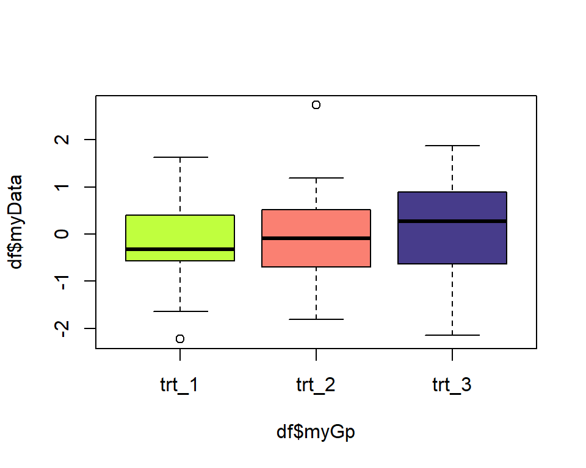

```r
myCol <- c("olivedrab1", "salmon", "slateblue4")
boxplot(df$myData ~ df$myGp,
  col = myCol[as.numeric(levels(df$myGp))],
  names = paste0("trt_",levels(df$myGp)))
```

## ANOVA

- Variable explicative qualitative (type `factor`) : “1”, “3”, ou “2”
- Variable à expliquer quantitative continue : tirage au hasard dans une loi Normale de paramètres $\mu = 0$ et $\sigma = 1$.

Ici nous avons 1 **facteur** qui prend comme **niveaux** (ou **modalités**) “1”, “2”, “3” ($p = 3$), et pour chaque niveau un échantillon de taille 30 (plan équilibré $n_1 = ... = n_p$).

## ANOVA

```r
tapply(df$myData, INDEX = df$myGp, FUN = length)
```

```
##  1  2  3
## 30 30 30
```

```r
tapply(df$myData, INDEX = df$myGp, FUN = summary)
```

```
## $`1`
##    Min. 1st Qu.  Median    Mean 3rd Qu.    Max.
## -2.2255 -0.5591 -0.3282 -0.2135  0.3695  1.6295
##
## $`2`
##     Min.  1st Qu.   Median     Mean  3rd Qu.     Max.
## -1.81087 -0.67476 -0.08768 -0.05888  0.48434  2.73521
##
## $`3`
##     Min.  1st Qu.   Median     Mean  3rd Qu.     Max.
## -2.14386 -0.59020  0.27771  0.09969  0.86047  1.86804
```

## ANOVA

Nous allons tester si la moyenne des différents groupes est la même ou pas = mettre en évidence une différence de valeur moyenne selon le **niveau** du **facteur**.

$Y_j=\mu + \alpha_j + \epsilon_j, j=1,... ,p$

$H_0: \alpha_1 = ... = \alpha_j = ... = \alpha_P$

## ANOVA

On suppose :

$y_{ij}=\mu+\alpha_j+\epsilon_{ij}, i=1,...,n_j, j=1,...,p$

## ANOVA

Dans notre modèle, on ne connait pas $\mu$, et $\alpha_1,...,\alpha_p$, ce qui fait $p+1$ inconnus. Comme nous n’avons que $p$ groupes, on impose que :

$\sum_{j=1}^{p}n_j\alpha_j=0$

compensation entre groupes

## ANOVA

On minimise (moindres carrés) :

$\sum_{i}\sum_{j}(y_{ij}-\alpha_j-\mu)^2$

## ANOVA

Somme des carrés des variations dans le niveau j

$D_j = \sum(y_{ij}-\overline{y}_j)^2$

```r
Dj <- sapply(levels(df$myGp), function(j){
  sum((df$myData[df$myGp == j] -
    mean(df$myData[df$myGp == j]))^2)
})
print(Dj)
```

```
##        1        2        3
## 21.99745 25.23369 34.23868
```

## ANOVA

Somme des carrés des variations intra-niveaux

$SS_{intra}=\sum_jD_j=(n-p)S^2$

```r
SSintra <- sum(Dj)
print(SSintra)
```

```
## [1] 81.46982
```

## ANOVA

Somme des carrés des variations inter-niveaux (SSE)

$SS_{inter}=\sum_jnj(\overline{y}_j-\overline{y})^2$

```r
SSinter <- sum(sapply(levels(df$myGp), function(j){
  length(df$myData[df$myGp == j]) *
    (mean(df$myData[df$myGp == j]) -
      mean(df$myData))^2
}))
print(SSinter)
```

```
## [1] 1.471524
```

## ANOVA

Somme des carrés des variations totales (SST)

$SST = \sum(y_{ij}-\overline{y})^2$

```r
SST <- sum((df$myData - mean(df$myData))^2)
print(SST)
```

```
## [1] 82.94134
```

## ANOVA

$SST=SS_{inter}+SS_{intra}$

```r
print(SSinter + SSintra)
```

```
## [1] 82.94134
```

```r
print(SST)
```

```
## [1] 82.94134
```

## ANOVA

Indice de qualité : pourcentage de variation expliqué par le modèle

$\eta^2=SS_{inter}/SST$

```r
eta2 <- SSinter / SST
print(eta2)
```

```
## [1] 0.01774174
```

## ANOVA

Indice de Fisher

$F=\frac{SS_{inter}/(p-1)}{SS_{intra}/n-p}$

```r
Fi <- (SSinter/(3-1)) / (SSintra/(90-3))
print(Fi)
```

```
## [1] 0.7857056
```

## ANOVA en images… (the R book)

```r
plot(df$myData, type = 'n', axes = FALSE,
  xlab = "", ylab = "")
axis(1)
axis(2)
df <- df[order(df$myGp),]
rownames(df) <- NULL
trash <- lapply(levels(df$myGp), function(p){
  points(
    x = as.numeric(rownames(df[df$myGp == p,])),
    y = df$myData[df$myGp == p],
    col = as.numeric(p), pch = 16)
})
```

## ANOVA en images…

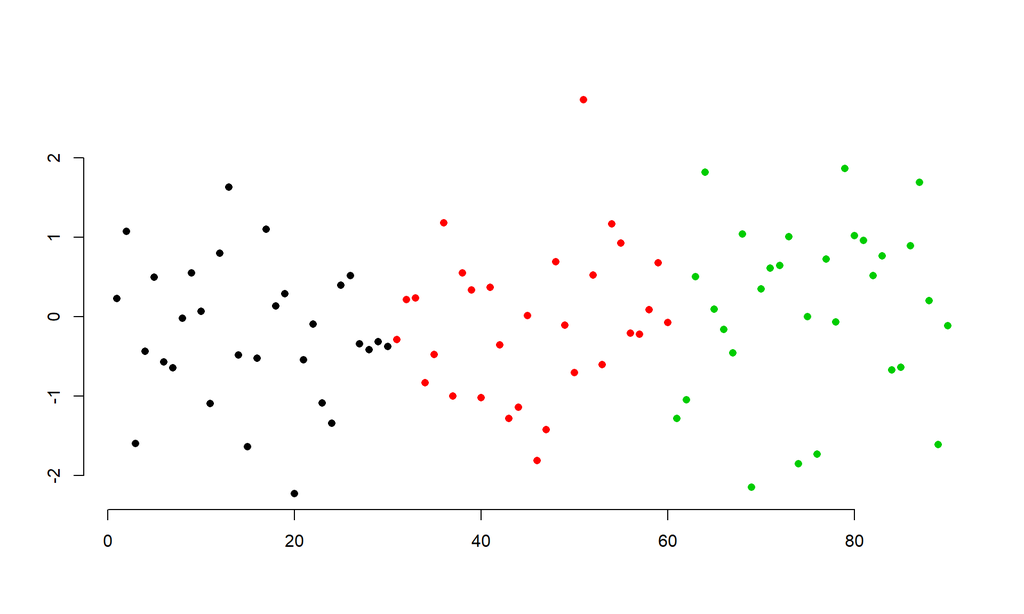

## ANOVA en images…

```r
plot(df$myData, type = 'n', axes = FALSE,
  xlab = "", ylab = "")
axis(1)
axis(2)
df <- df[order(df$myGp),]
rownames(df) <- NULL
trash <- lapply(levels(df$myGp), function(p){
  points(
    x = as.numeric(rownames(df[df$myGp == p,])),
    y = df$myData[df$myGp == p],
    col = as.numeric(p), pch = 16)
})
abline(h = mean(df$myData))
segments(
  x0 = 1:nrow(df),
  y0 = rep(mean(df$myData), nrow(df)),
  x1 = 1:nrow(df),
  y1 = df$myData)
```

## ANOVA en images…

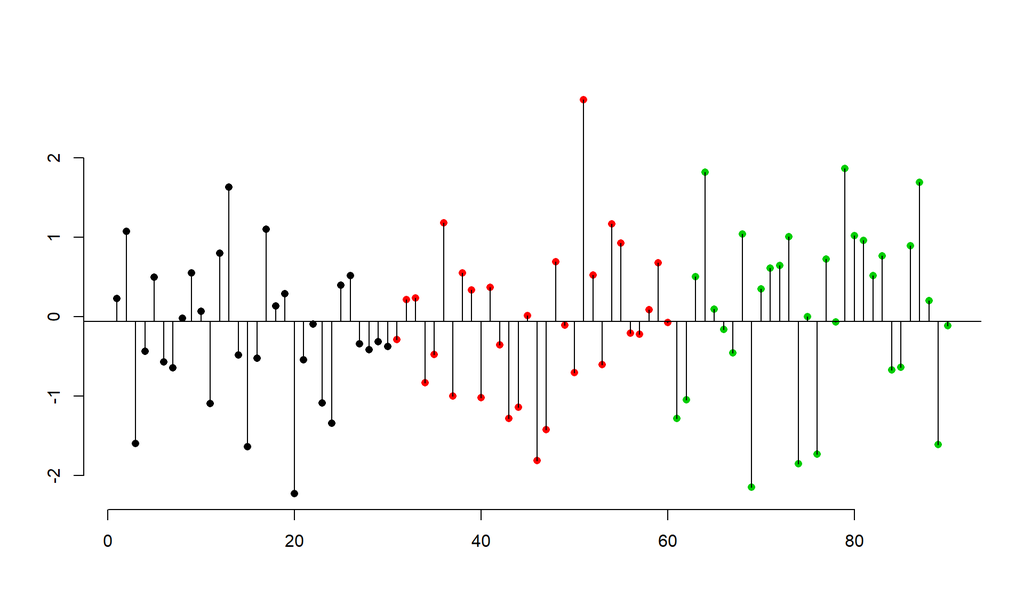

## ANOVA en images…

Représentation de la variance totale.

Somme des carrés des variations totales (SST)

$SST = \sum(y_{ij}-\overline{y})^2$

```r
SST <- sum((df$myData - mean(df$myData))^2)
print(SST)
```

```
## [1] 82.94134
```

## ANOVA en images…

```r
plot(df$myData, type = 'n', axes = FALSE,
  xlab = "", ylab = "")
axis(1)
axis(2)
df <- df[order(df$myGp),]
rownames(df) <- NULL
trash <- lapply(levels(df$myGp), function(p){
  points(
    x = as.numeric(rownames(df[df$myGp == p,])),
    y = df$myData[df$myGp == p],
    col = as.numeric(p), pch = 16)
})
trash <- lapply(levels(df$myGp), function(p){
  points(
    x = as.numeric(rownames(df[df$myGp == p,])),
    y = df$myData[df$myGp == p],
    col = as.numeric(p), pch = 16)
  segments(
    x0 = as.numeric(rownames(df[df$myGp == p,])),
    y0 = mean(df$myData[df$myGp == p]),
    x1 = as.numeric(rownames(df[df$myGp == p,])),
    y1 = df$myData[df$myGp == p], col = p
  )
  segments(
    x0 = as.numeric(rownames(df[df$myGp == p,]))[1],
    x1 = tail(as.numeric(rownames(df[df$myGp == p,])),1),
    y0 = mean(df$myData[df$myGp == p]),
    y1 = mean(df$myData[df$myGp == p]), col = p
  )
})
```

## ANOVA en images…

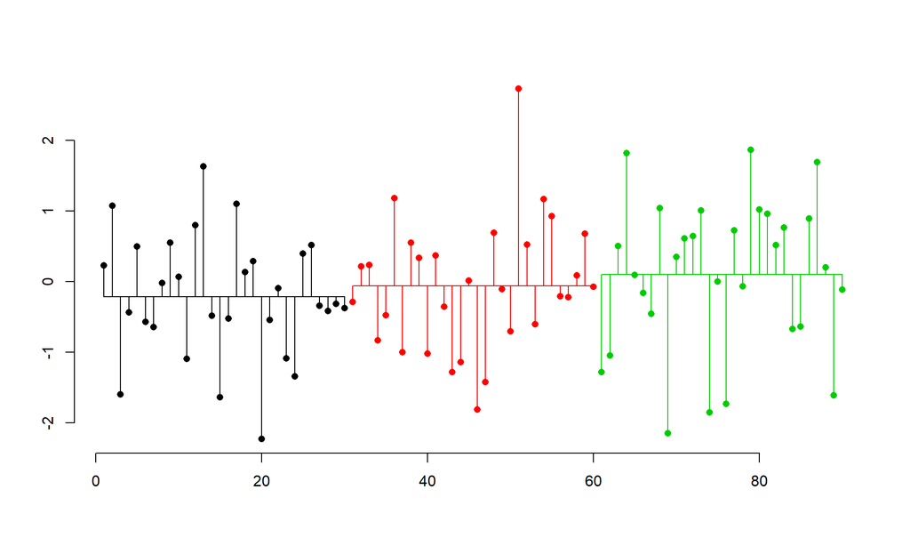

## ANOVA en images…

Somme des carrés des variations intra-niveaux

$SS_{intra}=\sum_jD_j=(n-p)S^2$

$D_j = \sum(y_{ij}-\overline{y}_j)^2$

```r
Dj <- sapply(levels(df$myGp), function(j){
  sum((df$myData[df$myGp == j] -
    mean(df$myData[df$myGp == j]))^2)
})
SSintra <- sum(Dj)
print(SSintra)
```

```
## [1] 81.46982
```

## ANOVA en images…

Si $SST = SS_{intra}$, pas de différence entre moyennes.

Calcul de $SS_{inter} = SST - SS_{intra}$

=> quel seuil pour différence significqtive, test de Fisher sur les variances.

## ANOVA

Indice de Fisher

$F=\frac{SS_{inter}/(p-1)}{SS_{intra}/n-p}$

```r
Fi <- (SSinter/(3-1)) / (SSintra/(90-3))
print(Fi)
```

```
## [1] 0.7857056
```

```r
# seuil critique 5% (F(p-1;n-p))
qf(p=0.95, df1=3-1, df2=90-3)
```

```
## [1] 3.101296
```

## ANOVA

Validation des hypothèses

- échantillonnage aléatoire
- variances égales
- indépendance des erreurs
- distribution normale des erreurs

## ANOVA ; variances

```r
tapply(df$myData, INDEX = df$myGp, FUN = var)
```

```
##         1         2         3
## 0.7585327 0.8701273 1.1806440
```

```r
# Flinger-Killen : homogeneité des variances
fligner.test(df$myData ~ df$myGp)
```

```
##
##  Fligner-Killeen test of homogeneity of variances
##
## data:  df$myData by df$myGp
## Fligner-Killeen:med chi-squared = 1.836, df = 2, p-value = 0.3993
```

## ANOVA

```r
summary(aov(df$myData ~ df$myGp))
```

```
##             Df Sum Sq Mean Sq F value Pr(>F)
## df$myGp      2   1.47  0.7358   0.786  0.459
## Residuals   87  81.47  0.9364
```

## ANOVA ; hypothèses

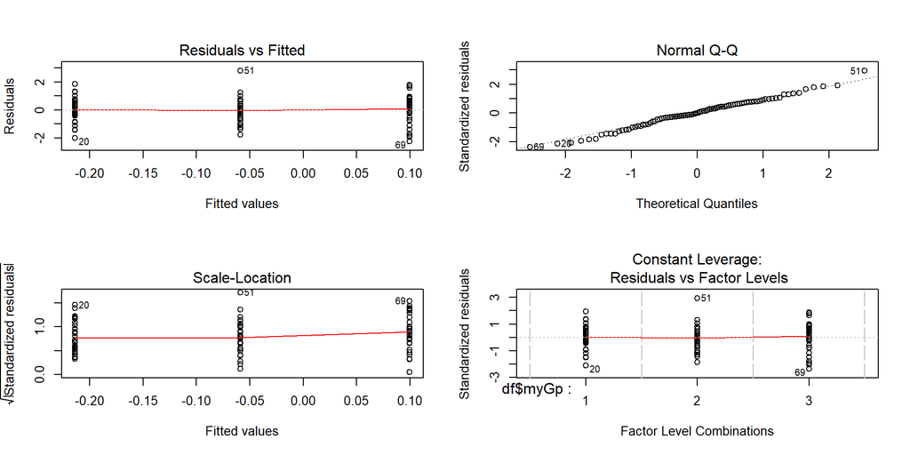

```r
par(mfrow = c(2, 2), ask = FALSE)
plot(aov(df$myData ~ df$myGp))
```

## ANOVA ; hypothèses

graph 1 : variances égales

graph 2 : distribution normale des erreurs

grpah 3/4 : indépendance des erreurs

# ANOVA 2 facteurs - design équilibré

## ANOVA 2f

- ANOVA à 2 facteurs
- *Two-way ANOVA*

## ANOVA 2f

```r
df2 <- data.frame(
  myData = rnorm(360),
  myGp1 = rep(c("t1", "t2", "t3"), each = 120),
  myGp2 = rep(c("x1", "x2", "x3", "x4"), times = 90)
)
```

## ANOVA 2f : hypothèses

- Il n’y a pas de différence entre moyennes pour le groupe 1
- Il n’y a pas de différence entre moyennes pour le groupe 2
- Il n’y a pas d’interaction antre les groupes 1 et 2

## ANOVA 2f

Cas d’un design équilibré 3x4 : 30 observations par combinaison de facteurs.

```r
table(df2$myGp1, df2$myGp2)
```

```
##
##      x1 x2 x3 x4
##   t1 30 30 30 30
##   t2 30 30 30 30
##   t3 30 30 30 30
```

## ANOVA 2f

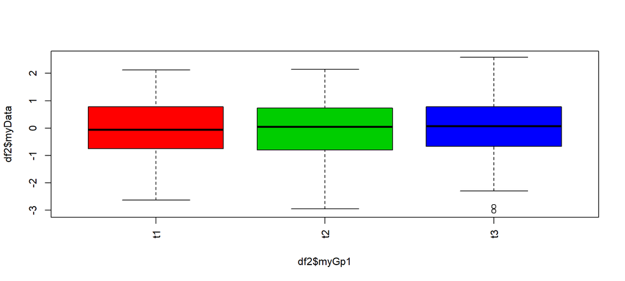

```r
boxplot(df2$myData ~ df2$myGp1,
  col = c(2:4), las = 3)
```

## ANOVA 2f

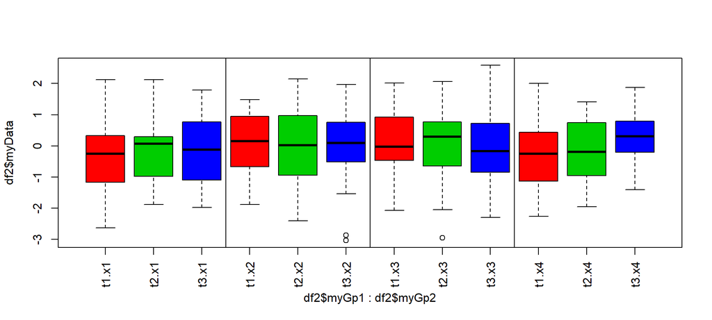

```r
boxplot(df2$myData ~ df2$myGp1 + df2$myGp2,
  col = c(2:4), las = 3)
abline(v = c(3.5, 6.5, 9.5))
```

## ANOVA 2f

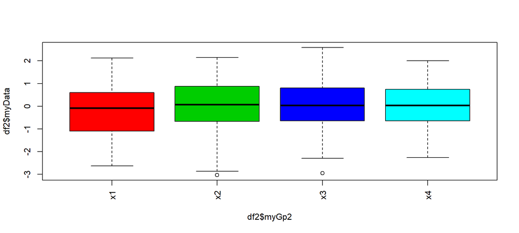

```r
boxplot(df2$myData ~ df2$myGp2,
  col = c(2:5), las = 3)
```

## ANOVA 2f

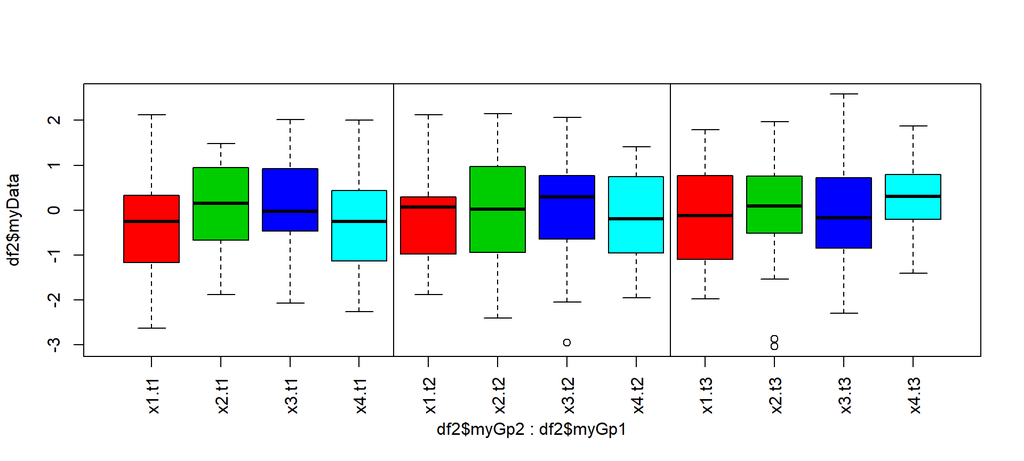

```r
boxplot(df2$myData ~ df2$myGp2 + df2$myGp1,
  col = c(2:5), las = 3)
abline(v = c(4.5, 8.5))
```

## ANOVA 2f

```r
interaction.plot(
  x.factor = df2$myGp1,
  trace.factor = df2$myGp2,
  response = df2$myData,
  fun = mean,
  type = "b", legend = TRUE,
  xlab = "Treatment", ylab="Results",
  pch = c(1, 19), col = 1:4)
```

## ANOVA 2f

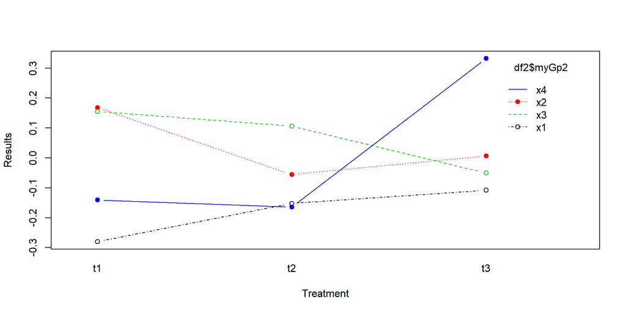

## ANOVA 2f (additif : pas d’interaction)

```r
res2 <- aov(myData ~ myGp1 + myGp2, data = df2)
summary(res2)
```

```
##              Df Sum Sq Mean Sq F value Pr(>F)
## myGp1         2    0.8  0.3806   0.338  0.713
## myGp2         3    3.4  1.1412   1.014  0.386
## Residuals   354  398.4  1.1254
```

## ANOVA 2f (test interaction)

```r
res3 <- aov(myData ~ myGp1 * myGp2, data = df2)
summary(res3)
```

```
##              Df Sum Sq Mean Sq F value Pr(>F)
## myGp1         2    0.8  0.3806   0.338  0.714
## myGp2         3    3.4  1.1412   1.012  0.387
## myGp1:myGp2   6    5.9  0.9843   0.873  0.515
## Residuals   348  392.5  1.1278
```

## ANOVA 2f (stats descriptives)

```r
model.tables(res2, type = "means", se = TRUE)
```

```
## Tables of means
## Grand mean
##
## -0.01544385
##
##  myGp1
## myGp1
##       t1       t2       t3
## -0.02459 -0.06664  0.04489
##
##  myGp2
## myGp2
##       x1       x2       x3       x4
## -0.18015  0.03959  0.06999  0.00879
##
## Standard errors for differences of means
##          myGp1  myGp2
##         0.1370 0.1581
## replic.    120     90
```

## ANOVA 2f + Tukey Honest Significant Differences

Comparaisons mutliples 2 à 2.

```r
TukeyHSD(res2)
```

```
##   Tukey multiple comparisons of means
##     95% family-wise confidence level
##
## Fit: aov(formula = myData ~ myGp1 + myGp2, data = df2)
##
## $myGp1
##              diff        lwr       upr     p adj
## t2-t1 -0.04204985 -0.3643853 0.2802856 0.9493698
## t3-t1  0.06947382 -0.2528616 0.3918092 0.8678456
## t3-t2  0.11152367 -0.2108118 0.4338591 0.6943992
##
## $myGp2
##              diff        lwr       upr     p adj
## x2-x1  0.21973424 -0.1884690 0.6279375 0.5067607
## x3-x1  0.25013522 -0.1580680 0.6583385 0.3903686
## x4-x1  0.18893809 -0.2192652 0.5971413 0.6305677
## x3-x2  0.03040098 -0.3778023 0.4386042 0.9974783
## x4-x2 -0.03079615 -0.4389994 0.3774071 0.9973796
## x4-x3 -0.06119713 -0.4694004 0.3470061 0.9802826
```

## ANOVA 2f

```r
df3 <- data.frame(
  myData = c(
    rnorm(120),
    rnorm(120, mean = 2),
    rnorm(120, mean = 5)),
  myGp1 = rep(c("t1", "t2", "t3"), each = 120),
  myGp2 = rep(c("x1", "x2", "x3", "x4"), times = 90)
)
```

## ANOVA 2f

```r
res4 <- aov(myData ~ myGp1 + myGp2, data = df3)
summary(res4)
```

```
##              Df Sum Sq Mean Sq F value Pr(>F)
## myGp1         2 1621.0   810.5 783.344 <2e-16 ***
## myGp2         3    4.2     1.4   1.339  0.262
## Residuals   354  366.3     1.0
## ---
## Signif. codes:  0 '***' 0.001 '**' 0.01 '*' 0.05 '.' 0.1 ' ' 1
```

## ANOVA 2f

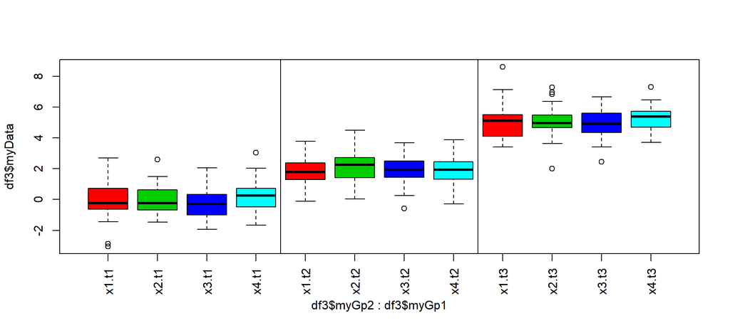

```r
boxplot(df3$myData ~ df3$myGp2 + df3$myGp1,
  col = c(2:5), las = 3)
abline(v = c(4.5, 8.5))
```

## ANOVA 2f

```r
TukeyHSD(res4)
```

```
##   Tukey multiple comparisons of means
##     95% family-wise confidence level
##
## Fit: aov(formula = myData ~ myGp1 + myGp2, data = df3)
##
## $myGp1
##           diff      lwr      upr p adj
## t2-t1 1.951714 1.642644 2.260783     0
## t3-t1 5.147817 4.838748 5.456886     0
## t3-t2 3.196103 2.887034 3.505173     0
##
## $myGp2
##              diff        lwr       upr     p adj
## x2-x1  0.15256917 -0.2388340 0.5439724 0.7459037
## x3-x1 -0.10751430 -0.4989175 0.2838889 0.8934836
## x4-x1  0.14156625 -0.2498369 0.5329694 0.7868022
## x3-x2 -0.26008347 -0.6514867 0.1313197 0.3172379
## x4-x2 -0.01100292 -0.4024061 0.3804003 0.9998627
## x4-x3  0.24908056 -0.1423226 0.6404837 0.3560447
```

## ANOVA 2f

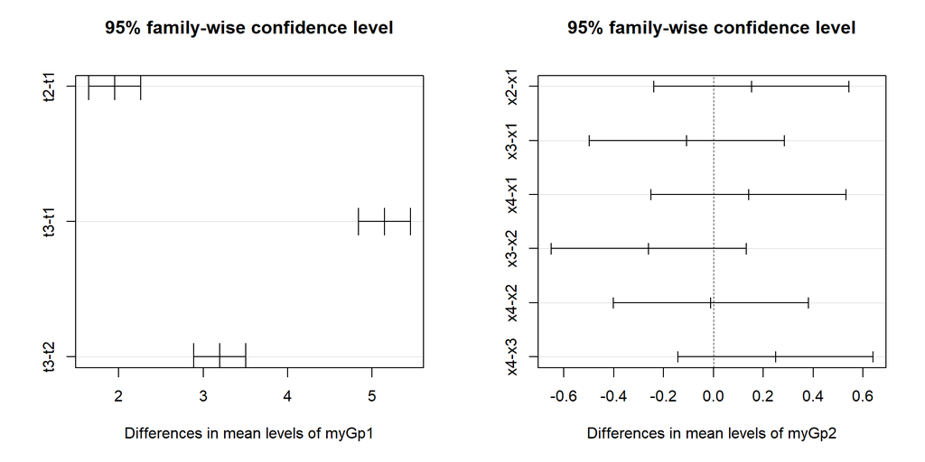

```r
par(mfrow = c(1, 2))
plot(TukeyHSD(res4))
```

# ANOVA 2 facteurs - design non équilibré

## ANOVA (design non équilibré)

… quand il n’y a pas le même nombre d’observations pour toutes les modalités !

## ANOVA

```r
df4b <- data.frame(
  myData = c(
    rnorm(240),
    rnorm(240, mean = 2),
    rnorm(240, mean = 5)),
  myGp1 = rep(c("t1", "t2", "t3"), each = 240),
  myGp2 = rep(c("x1", "x2", "x3", "x4"), times = 180)
)
sampleRow <- sample(1:nrow(df4b), size = 701)
df5 <- df4b[sampleRow, ]
```

## ANOVA 2f

```r
table(df5$myGp1, df5$myGp2)
```

```
##
##      x1 x2 x3 x4
##   t1 59 58 59 58
##   t2 59 60 57 59
##   t3 57 59 57 59
```

## ANOVA et les types I, II, et III

En bref : Il y a différentes façons de calculer les sommes des carrés (SS). Il existe trois approches que l’on appelle I, II et III. si le design est non équilibré, il faut utiliser le type III alors que R utilise le type I par default. Le package *car* a une fonction prête à l’emploi pour faire cela.

## ANOVA : fonction Anova du package “car”

```r
pkgCheck <- function(x){
    if (!require(x, character.only = TRUE)){
        install.packages(x, dependencies = TRUE)
        if(!require(x, character.only = TRUE)) {
            stop()
        }
    }
}
pkgCheck("car")
```

## ANOVA et les types I, II, et III

```r
myAnova <- aov(df5$myData ~ df5$myGp1 * df5$myGp2)
Anova(myAnova, type = "III")
```

```
## Anova Table (Type III tests)
##
## Response: df5$myData
##                     Sum Sq  Df  F value Pr(>F)
## (Intercept)           0.05   1   0.0442 0.8335
## df5$myGp1           745.25   2 330.0907 <2e-16 ***
## df5$myGp2             0.23   3   0.0691 0.9764
## df5$myGp1:df5$myGp2   3.21   6   0.4740 0.8279
## Residuals           777.78 689
## ---
## Signif. codes:  0 '***' 0.001 '**' 0.01 '*' 0.05 '.' 0.1 ' ' 1
```

# ANOVA et Tukey

## ANOVA et Tukey

```r
dfx <- data.frame(
  myData = c(
    rnorm(60),
    rnorm(60, mean = 1),
    rnorm(60, mean = 2),
    rnorm(60, mean = 3),
    rnorm(60, mean = 4),
    rnorm(60, mean = 5)),
  myGp1 = rep(c(
    paste0("t0", 1:9),
    paste0("t", 10:12)), each = 30)
)
```

## ANOVA et Tukey

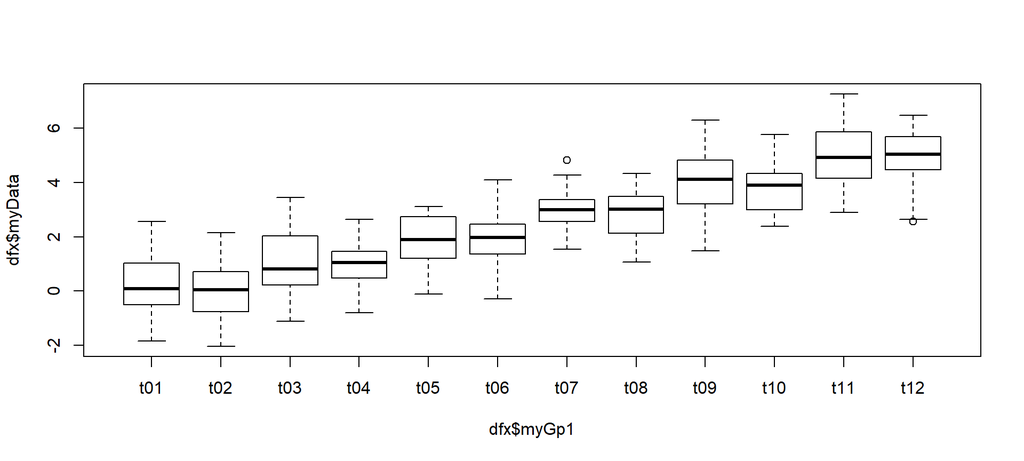

```r
boxplot(dfx$myData ~ dfx$myGp1)
```

## ANOVA et Tukey

```r
res6 <- aov(dfx$myData ~ dfx$myGp1)
summary(res6)
```

```
##              Df Sum Sq Mean Sq F value Pr(>F)
## dfx$myGp1    11 1030.1   93.65    92.6 <2e-16 ***
## Residuals   348  351.9    1.01
## ---
## Signif. codes:  0 '***' 0.001 '**' 0.01 '*' 0.05 '.' 0.1 ' ' 1
```

## ANOVA et Tukey

```r
TukeyHSD(res6)
```

```
##   Tukey multiple comparisons of means
##     95% family-wise confidence level
##
## Fit: aov(formula = dfx$myData ~ dfx$myGp1)
##
## $`dfx$myGp1`
##                diff          lwr       upr     p adj
## t02-t01 -0.16848654 -1.022889955 0.6859169 0.9999628
## t03-t01  0.88054403  0.026140621 1.7349474 0.0367186
## t04-t01  0.79325256 -0.061150852 1.6476560 0.0976784
## t05-t01  1.64335011  0.788946697 2.4977535 0.0000000
## t06-t01  1.73215061  0.877747199 2.5865540 0.0000000
## t07-t01  2.84750503  1.993101614 3.7019084 0.0000000
## t08-t01  2.80697791  1.952574494 3.6613813 0.0000000
## t09-t01  3.90891647  3.054513053 4.7633199 0.0000000
## t10-t01  3.66854689  2.814143479 4.5229503 0.0000000
## t11-t01  4.85723744  4.002834028 5.7116409 0.0000000
## t12-t01  4.82186201  3.967458596 5.6762654 0.0000000
## t03-t02  1.04903058  0.194627164 1.9034340 0.0037493
## t04-t02  0.96173910  0.107335690 1.8161425 0.0129900
## t05-t02  1.81183665  0.957433239 2.6662401 0.0000000
## t06-t02  1.90063715  1.046233742 2.7550406 0.0000000
## t07-t02  3.01599157  2.161588156 3.8703950 0.0000000
## t08-t02  2.97546445  2.121061037 3.8298679 0.0000000
## t09-t02  4.07740301  3.222999596 4.9318064 0.0000000
## t10-t02  3.83703343  2.982630021 4.6914368 0.0000000
## t11-t02  5.02572398  4.171320570 5.8801274 0.0000000
## t12-t02  4.99034855  4.135945138 5.8447520 0.0000000
## t04-t03 -0.08729147 -0.941694886 0.7671119 1.0000000
## t05-t03  0.76280608 -0.091597337 1.6172095 0.1324546
## t06-t03  0.85160658 -0.002796835 1.7060100 0.0516390
## t07-t03  1.96696099  1.112557580 2.8213644 0.0000000
## t08-t03  1.92643387  1.072030460 2.7808373 0.0000000
## t09-t03  3.02837243  2.173969020 3.8827758 0.0000000
## t10-t03  2.78800286  1.933599445 3.6424063 0.0000000
## t11-t03  3.97669341  3.122289994 4.8310968 0.0000000
## t12-t03  3.94131797  3.086914562 4.7957214 0.0000000
## t05-t04  0.85009755 -0.004305864 1.7045010 0.0525422
## t06-t04  0.93889805  0.084494639 1.7933015 0.0176078
## t07-t04  2.05425247  1.199849053 2.9086559 0.0000000
```

[output cut: 18 more lines]

```
## t08-t07 -0.04052712 -0.894930532 0.8138763 1.0000000
## t09-t07  1.06141144  0.207008027 1.9158149 0.0031127
## t10-t07  0.82104187 -0.033361547 1.6754453 0.0727277
## t11-t07  2.00973241  1.155329001 2.8641358 0.0000000
## t12-t07  1.97435698  1.119953569 2.8287604 0.0000000
## t09-t08  1.10193856  0.247535147 1.9563420 0.0016653
## t10-t08  0.86156898  0.007165572 1.7159724 0.0460024
## t11-t08  2.05025953  1.195856121 2.9046629 0.0000000
## t12-t08  2.01488410  1.160480689 2.8692875 0.0000000
## t10-t09 -0.24036957 -1.094772987 0.6140338 0.9988276
## t11-t09  0.94832097  0.093917562 1.8027244 0.0155484
## t12-t09  0.91294554  0.058542130 1.7673490 0.0246018
## t11-t10  1.18869055  0.334287136 2.0430940 0.0004027
## t12-t10  1.15331512  0.298911704 2.0077185 0.0007278
## t12-t11 -0.03537543 -0.889778845 0.8190280 1.0000000
```

## ANOVA et Tukey

```r
# adapted from https://www.r-graph-gallery.com/84-tukey-test.html
pkgCheck <- function(x){
    if (!require(x, character.only = TRUE)){
        install.packages(x, dependencies = TRUE)
        if(!require(x, character.only = TRUE)) {
            stop()
        }
    }
}
pkgCheck("multcompView")
tuk <- TukeyHSD(res6)
generate_label_df <- function(TUKEY, variable){
  Tukey.levels <- TUKEY[[variable]][,4]
  Tukey.labels <- data.frame(multcompLetters(Tukey.levels)['Letters'])
  Tukey.labels$treatment=rownames(Tukey.labels)
  Tukey.labels=Tukey.labels[order(Tukey.labels$treatment) , ]
  return(Tukey.labels)
}
LABELS <- generate_label_df(TUKEY = tuk, "dfx$myGp1")
myCol <- sample(colors(), size = 50)
boxA <- boxplot(dfx$myData ~ dfx$myGp1,
  ylim=c(min(dfx$myData), 1.1*max(dfx$myData)),
  col = myCol[as.numeric(LABELS[,1])])
over <- 0.1 * max(boxA$stats[nrow(boxA$stats),])
text(
  x = c(1:nlevels(dfx$myGp1)),
  y = boxA$stats[nrow(boxA$stats),] + over,
  labels = LABELS[,1],
  col = 1)
```

## ANOVA et Tukey

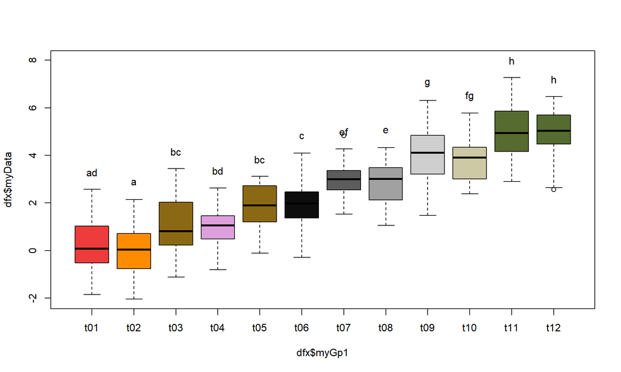

## ANOVA et Tukey

```r
# adapted from https://www.r-graph-gallery.com/84-tukey-test.html
tuk <- TukeyHSD(res6)
generate_label_df <- function(TUKEY, variable){
  Tukey.levels <- TUKEY[[variable]][,4]
  Tukey.labels <- data.frame(multcompLetters(Tukey.levels)['Letters'])
  Tukey.labels$treatment=rownames(Tukey.labels)
  Tukey.labels=Tukey.labels[order(Tukey.labels$treatment) , ]
  return(Tukey.labels)
}
LABELS <- generate_label_df(TUKEY = tuk, "dfx$myGp1")
myCol <- sample(colors(), size = 50)
boxA <- boxplot(dfx$myData ~ dfx$myGp1,
  ylim=c(min(dfx$myData), 1.1*max(dfx$myData)),
  col = myCol[as.numeric(LABELS[,1])],
  axes = FALSE, xlab = "", ylab = "")
grid()
axis(1, at = 1:12, labels = levels(dfx$myGp1))
axis(2)
over <- 0.1 * max(boxA$stats[nrow(boxA$stats),])
text(
  x = c(1:nlevels(dfx$myGp1)),
  y = boxA$stats[nrow(boxA$stats),] + over,
  labels = LABELS[,1],
  col = 1)
```

## ANOVA et Tukey

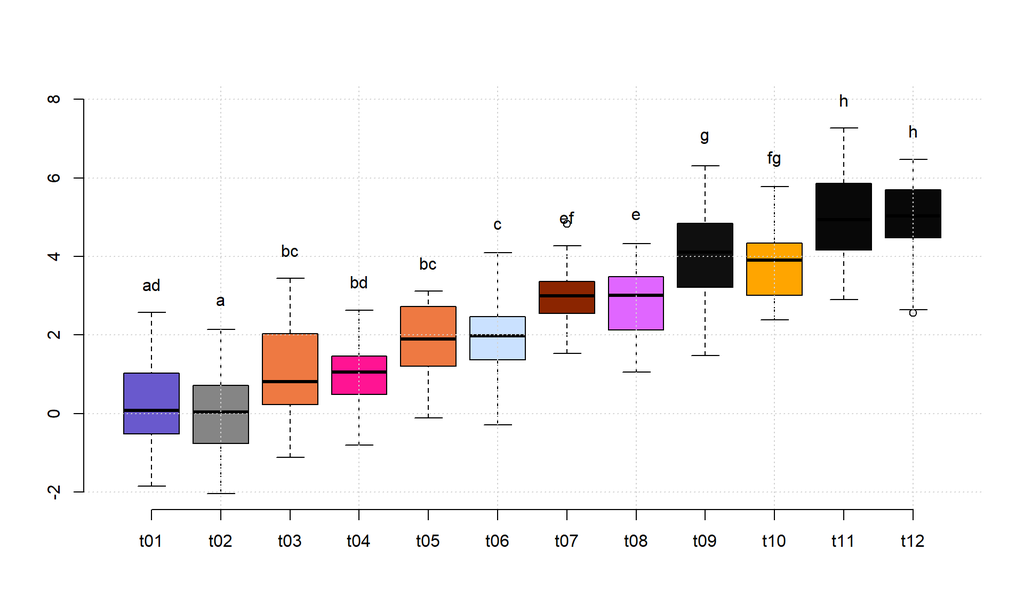

# ANOVA et hypothèses non vérifiées

Lorsque la variable à expliquer ne suit pas une loi Normale, nous pouvons transformer les données. Les transformations utilisent le plus souvent le log ou la puissance.

InsecrSprays : The counts of insects in agricultural experimental units treated with different insecticides.

```r
data(InsectSprays)
head(InsectSprays)
```

```
##   count spray
## 1    10     A
## 2     7     A
## 3    20     A
## 4    14     A
## 5    14     A
## 6    12     A
```

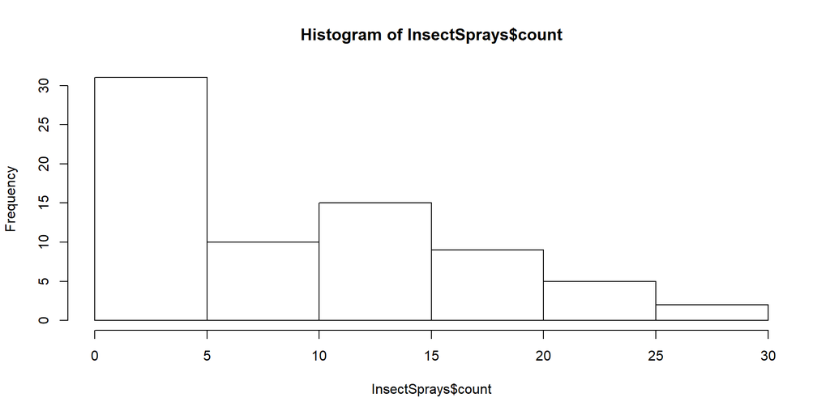

```r
hist(InsectSprays$count)
```

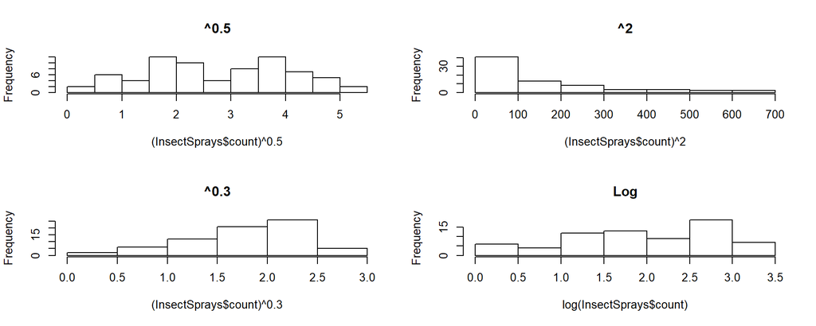

```r
par(mfrow = c(2, 2))
hist((InsectSprays$count)^0.5, main = "^0.5")
hist((InsectSprays$count)^2, main = "^2")
hist((InsectSprays$count)^0.3, main = "^0.3")
hist(log(InsectSprays$count), main = "Log")
```

```r
mod01 <- aov(sqrt(InsectSprays$count) ~ InsectSprays$spray)
summary(mod01)
```

```
##                    Df Sum Sq Mean Sq F value Pr(>F)
## InsectSprays$spray  5  88.44  17.688    44.8 <2e-16 ***
## Residuals          66  26.06   0.395
## ---
## Signif. codes:  0 '***' 0.001 '**' 0.01 '*' 0.05 '.' 0.1 ' ' 1
```

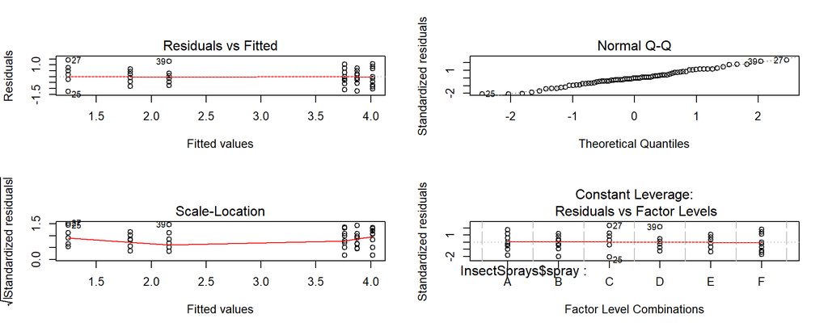

```r
par(mfrow = c(2, 2))
plot(mod01)
```

```r
shapiro.test(resid(mod01)) # normalité résidus
```

```
##
##  Shapiro-Wilk normality test
##
## data:  resid(mod01)
## W = 0.98721, p-value = 0.6814
```

```r
bartlett.test( # homogénéité de la variance
  sqrt(InsectSprays$count) ~ InsectSprays$spray)
```

```
##
##  Bartlett test of homogeneity of variances
##
## data:  sqrt(InsectSprays$count) by InsectSprays$spray
## Bartlett's K-squared = 3.7525, df = 5, p-value = 0.5856
```

```r
pkgCheck("lmtest")
dwtest(mod01) # indépendance des résidus
```

```
##
##  Durbin-Watson test
##
## data:  mod01
## DW = 1.8804, p-value = 0.1325
## alternative hypothesis: true autocorrelation is greater than 0
```

## Autres cas

warpbreaks : This data set gives the number of warp breaks per loom, where a loom corresponds to a fixed length of yarn.

```r
data(warpbreaks)
head(warpbreaks)
```

```
##   breaks wool tension
## 1     26    A       L
## 2     30    A       L
## 3     54    A       L
## 4     25    A       L
## 5     70    A       L
## 6     52    A       L
```

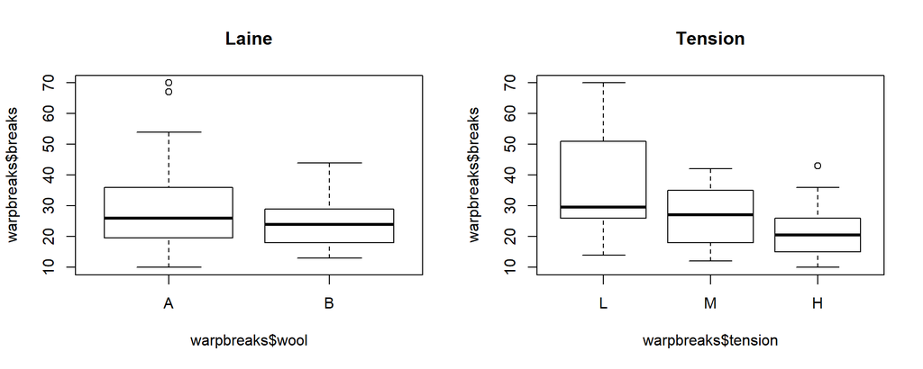

```r
par(mfrow = c(1, 2))
boxplot(warpbreaks$breaks ~ warpbreaks$wool, main = "Laine")
boxplot(warpbreaks$breaks ~ warpbreaks$tension, main = "Tension")
```

```r
mod02 <- aov(warpbreaks$breaks ∼ warpbreaks$wool * warpbreaks$tension)
summary(mod02)
```

```
##                                    Df Sum Sq Mean Sq F value   Pr(>F)
## warpbreaks$wool                     1    451   450.7   3.765 0.058213 .
## warpbreaks$tension                  2   2034  1017.1   8.498 0.000693 ***
## warpbreaks$wool:warpbreaks$tension  2   1003   501.4   4.189 0.021044 *
## Residuals                          48   5745   119.7
## ---
## Signif. codes:  0 '***' 0.001 '**' 0.01 '*' 0.05 '.' 0.1 ' ' 1
```

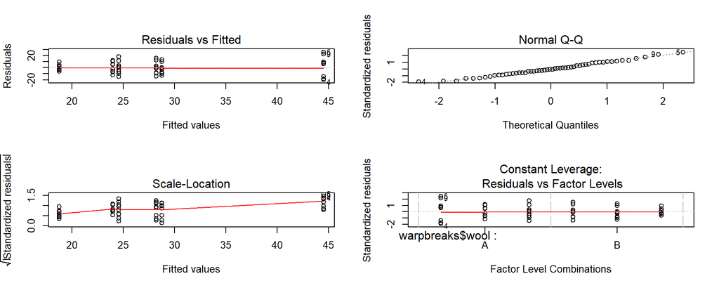

```r
par(mfrow = c(2, 2))
plot(mod02) # pb homogénéité de la variance
```

```r
bartlett.test(warpbreaks$breaks, warpbreaks$wool)
```

```
##
##  Bartlett test of homogeneity of variances
##
## data:  warpbreaks$breaks and warpbreaks$wool
## Bartlett's K-squared = 6.9314, df = 1, p-value = 0.00847
```

```r
bartlett.test(warpbreaks$breaks, warpbreaks$tension)
```

```
##
##  Bartlett test of homogeneity of variances
##
## data:  warpbreaks$breaks and warpbreaks$tension
## Bartlett's K-squared = 9.6571, df = 2, p-value = 0.007998
```

```r
mod03 <- aov(log(warpbreaks$breaks) ∼
  warpbreaks$wool * warpbreaks$tension)
summary(mod03)
```

```
##                                    Df Sum Sq Mean Sq F value  Pr(>F)
## warpbreaks$wool                     1  0.313  0.3125   2.234 0.14151
## warpbreaks$tension                  2  2.176  1.0881   7.779 0.00118 **
## warpbreaks$wool:warpbreaks$tension  2  0.913  0.4566   3.264 0.04686 *
## Residuals                          48  6.714  0.1399
## ---
## Signif. codes:  0 '***' 0.001 '**' 0.01 '*' 0.05 '.' 0.1 ' ' 1
```

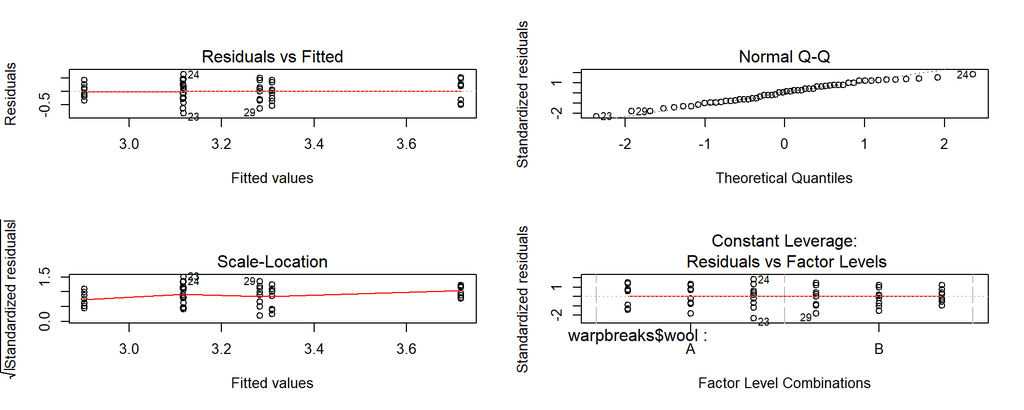

```r
par(mfrow = c(2, 2))
plot(mod03)
```

```r
shapiro.test(resid(mod03))
```

```
##
##  Shapiro-Wilk normality test
##
## data:  resid(mod03)
## W = 0.97292, p-value = 0.2583
```

```r
bartlett.test(log(warpbreaks$breaks), warpbreaks$wool)
```

```
##
##  Bartlett test of homogeneity of variances
##
## data:  log(warpbreaks$breaks) and warpbreaks$wool
## Bartlett's K-squared = 2.3674, df = 1, p-value = 0.1239
```

```r
bartlett.test(log(warpbreaks$breaks), warpbreaks$tension)
```

```
##
##  Bartlett test of homogeneity of variances
##
## data:  log(warpbreaks$breaks) and warpbreaks$tension
## Bartlett's K-squared = 0.94898, df = 2, p-value = 0.6222
```